# Exploring London's EU Referendum Vote through Ward based Census Data and Election Results

*Notebook created in April 2017*

## Part 1 - Machine Learning Analysis Workflow with Sci Kit Learn

[figure not shown]

## Background

With the recent calling of a snap uk election and last year's EU Referendum result still dominating discussion, it might be interesting to explore London's EU Ref Voting Preference through Census Data and its past electoral track record, as a means of trying out and illustrating some elementary aspects of data science analysis and the machine learning tools provided by the scikit python library.

**Questions**: What Ward Profile characteristics behind the London EU Vote? How does this relate to London's past Voting Record or Political Party Preferences?

Our starting point was a recent analysis published on the [BBC](http://www.bbc.co.uk/news/uk-politics-38762034), where Ward based breakdowns of the EU Referendum Vote had been collected from Local Councils via Freedom of Information Requests.

It identified several characterstics of the Remain and Leave Camp, including:

"The combination of education, age and ethnicity accounts for the large majority of the variation in votes between different places"

We will look at whether this relationship also applies to London as portrayed in its Census Profile and Election Result Data.

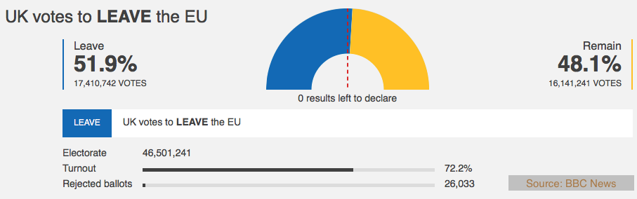

## Method

We will go through the steps of Data Preparation, Initial Cluster Analysis/Visualisation and then onto building a Classification Model following the main stages of Workflow Analysis:

- Standardisation
- Pre Processing
- Reorganisation
- Model Build
- Model Evaluation and Visualisation

### Initialize Workbook

```python
import numpy as np
import matplotlib.pyplot as plt
import pandas as pd

pd.set_option('display.max_rows', 800) # specifies number of rows to show
pd.set_option('display.max_columns', None) # specifies number of rows to show
pd.options.display.float_format = '{:40,.4f}'.format # specifies default number format to 4 decimal places
plt.style.use('classic') # specifies that graphs should use classic styling
%matplotlib inline
```

### Get Library Versions:

This jupyter notebook was written on Imac and MacBook, OSX El Capitan using Enthought Canopy Version: 1.7.4.3348

```python
np.__version__
#scikit version = 0.17-6
#statsmodels = 0.6.1-18
#numpy version = 1.11.3
#matplotlib version = 2.0.0-3
#seaborn version = 0.7.1-4
```

```
'1.17.2'
```

# 1 - Data Preparation and Inspection

### The Data:

Sources:

EU Ref Ward Results Data: http://newsimg.bbc.co.uk/news/special/2017/newsspec_15869/ward-results.xlsx  
2016 Mayoral Results Data: https://data.london.gov.uk/dataset/london-elections-results-2016-wards-boroughs-constituency  
Gen Election 2015 Results: https://data.london.gov.uk/dataset/general-election-results-2015  
2014 Council Election Results: https://data.london.gov.uk/dataset/borough-council-election-results-2014  
Constituency Ward Lookup Table: http://geoportal.statistics.gov.uk/datasets/f52c48ea5cf2494b824d35f4be88f2ec_0?uiTab=table  
London Ward Profile Data: https://data.london.gov.uk/dataset/ward-profiles-and-atlas

### Data Import:

```python
profile_data=pd.read_csv('ward-profiles-excel-version.csv', encoding = 'unicode_escape')
eu_results_data=pd.read_csv('eu_ref_results_ward.csv', encoding = 'unicode_escape')
council_results_data=pd.read_csv('2014_council_elections.csv', encoding = 'unicode_escape')
gla_results_data=pd.read_csv('gla-elections-votes-all-2016.csv', encoding = 'unicode_escape')
const_ward_lookup_data=pd.read_csv('lookup.csv', encoding = 'unicode_escape')
gen_elec_results_data=pd.read_csv('general-elections-votes-party-2015.csv', encoding = 'unicode_escape')
```

### Prepare EU Referendum Results:

```python
# check results
eu_results_data.head(1)

# remove nulls
eu_results_data =eu_results_data[eu_results_data['Remain%'].notnull() & (eu_results_data['Leave%'].notnull())]

# strip down to london
# not working - inner join will achieve same
eu_results_data = eu_results_data.loc[(eu_results_data['WardCode'].str.contains("E05000", na=False)
                    & pd.to_numeric(eu_results_data['WardCode'].str[6:8], errors='coerce') < 644)]


# strip out columns not interested in
eu_results_data = eu_results_data.iloc[:,[0,1,5,6,7]]

# create new df for results join
results_join_df = eu_results_data

results_join_df.head(1)
```

|  | WardCode | WardName | Postals | Remain% | Leave% |
| --- | --- | --- | --- | --- | --- |
| 83 | E05003286 | Codnor and Waingroves | NP | 28.9500 | 71.0500 |

### Join Council Election Results:

```python
# rename the lookup value
council_results_data = council_results_data.rename(columns = {'Ward_code':'WardCode'})
# group by Election Results Seat Count
council_results_data = pd.DataFrame(council_results_data.groupby(['Borough_code', 'WardCode', 'party'])['elected_flag'].count().reset_index())

# get index value of the max count in each grouping
idx = council_results_data.groupby('WardCode')['elected_flag'].idxmax()
# get matching index values and reset index to clean up dataframe
council_results_data = council_results_data.loc[idx, ['WardCode', 'party']].reset_index()

# rename the lookup value
council_results_data = council_results_data.rename(columns = {'party':'Council_Party'})

# strip out columns not interested in
#council_results_data = council_results_data_out.iloc[:,[1,2]]

# alt join code
#results_join_df = eu_results_data.join(council_results_data.set_index('WardCode'), on='WardCode')

results_join_df = pd.merge(eu_results_data, council_results_data, on='WardCode', how='inner')
results_join_df.head(1)
```

|  | WardCode | WardName | Postals | Remain% | Leave% | index | Council_Party |
| --- | --- | --- | --- | --- | --- | --- | --- |
| 0 | E05000106 | Bickley | P | 55.7400 | 44.2600 | 364 | CON |

### Join Mayoral Results:

```python
# rename the lookup value
gla_results_data = gla_results_data.rename(columns = {'Area Code':'WardCode'})
# strip out columns not interested in
gla_results_data = gla_results_data.iloc[:,[4,8]]
#join mayoral results to results df
results_join_df = pd.merge(results_join_df, gla_results_data, on='WardCode', how='inner')
results_join_df.head(1)
```

|  | WardCode | WardName | Postals | Remain% | Leave% | index | Council_Party | London Mayor |
| --- | --- | --- | --- | --- | --- | --- | --- | --- |
| 0 | E05000106 | Bickley | P | 55.7400 | 44.2600 | 364 | CON | Zac Goldsmith - The Conservative Party |

### Join General Election Results via Mayoral Constituency Lookup:

```python
#Fix for diff naming convention of st Pancras
#const_ward_lookup_data = const_ward_lookup_data.replace(['St. '],['St'])
gen_elec_results_data = gen_elec_results_data.replace({'St.': 'St '}, regex=True)
#const_ward_lookup_data.to_csv('const_ward_lookup_data_test.csv')
gen_elec_results_data.to_csv('gen_elec_results_data.csv')
gen_elec_results_data.head(1)
```

|  | Election year | Area Code | Constituency | Candidate name | Party abbreviation | Party | Candidate Votes | Candidate rank | Share of vote | Total constituency votes | Winning party | Majority | Electorate | % Turnout | % Majority | Gain/Hold |
| --- | --- | --- | --- | --- | --- | --- | --- | --- | --- | --- | --- | --- | --- | --- | --- | --- |
| 0 | 2015 | A11 | Barking | Margaret Hodge | Lab | Labour | 24,826 | 1 | 57.7000 | 43,023 | Lab | 15,272 | 74,050 | 58.1000 | 35.5000 | LAB HOLD |

```python
# rename the lookup values
const_ward_lookup_data = const_ward_lookup_data.rename(columns = {'WD16CD':'WardCode'})
# n.b. This doesnt work on all machines. Possibly to do with renaming of index.
# For now, i have manually changed the Col Header in the source file

const_ward_lookup_data = const_ward_lookup_data.rename(columns = {'PCON16NM':'Constituency'})

# strip out columns not interested in
const_ward_lookup_data = const_ward_lookup_data.iloc[:,[0,3]]
const_ward_lookup_data.head(1)
```

|  | WardCode | Constituency |
| --- | --- | --- |
| 0 | E05010888 | Bristol West |

```python
#remove null data/filter on winning party
gen_elec_results_data = gen_elec_results_data[gen_elec_results_data['Winning party'].notnull()]

#gen_elec_results_data = gen_elec_results_data.iloc[:,[2,5,15]]
#join gen election results to consitutency lookup
#N.B. holborn and st. pancras is missing from join due to the full stop after st

#inner join is lazy way to remove non london based rows
gen_elec_results_data = pd.merge(gen_elec_results_data, const_ward_lookup_data, on='Constituency', how='inner')
```

```python
gen_elec_results_data.head(1)
```

|  | Election year | Area Code | Constituency | Candidate name | Party abbreviation | Party | Candidate Votes | Candidate rank | Share of vote | Total constituency votes | Winning party | Majority | Electorate | % Turnout | % Majority | Gain/Hold | WardCode |
| --- | --- | --- | --- | --- | --- | --- | --- | --- | --- | --- | --- | --- | --- | --- | --- | --- | --- |
| 0 | 2015 | A11 | Barking | Margaret Hodge | Lab | Labour | 24,826 | 1 | 57.7000 | 43,023 | Lab | 15,272 | 74,050 | 58.1000 | 35.5000 | LAB HOLD | E05000026 |

```python
# strip out columns not interested in
# join gen elec results to results df
#results_join_df = results_join_df.join(gen_elec_results_data.set_index('WardCode'), on='WardCode')
results_join_df = pd.merge(results_join_df, gen_elec_results_data, on='WardCode', how='inner')
results_join_df = results_join_df.rename(columns = {'Party':'ConstituencyParty'})
```

### Final Data Join of Elections Results to Ward Profile Data

We now have a final data set mapping Ward Profile data to Borough Council Vote, Ward Mayoral Vote, MP Constituency vote and Ward to EU Referendum Vote:

```python
profile_data = profile_data.rename(columns = {'New code':'WardCode'})

#final_data = profile_data.join(results_join_df.set_index('WardCode'), on='WardCode')
final_data = pd.merge(results_join_df, profile_data, on='WardCode', how='inner')

#just keep the % Ward Profile Values and Ward Identifiers
final_data = final_data.filter(regex=('Ward|%|Council_Party|London Mayor|ConstituencyParty|Gain'))
final_data.head(1)
#Do we need to keep Postal or median house value, income ?????
```

|  | WardCode | WardName | Remain% | Leave% | Council_Party | London Mayor | ConstituencyParty | % Turnout | % Majority | Gain/Hold | Ward name | % All Children aged 0-15 - 2015 | % All Working-age (16-64) - 2015 | % All Older people aged 65+ - 2015 | % BAME - 2011 | % Not Born in UK - 2011 | % English is First Language of no one in household - 2011 | % children in reception year who are obese - 2011/12 to 2013/14 | % children in year 6 who are obese- 2011/12 to 2013/14 | % detached houses - 2011 | % semi-detached houses - 2011 | % terraced houses - 2011 | % Flat, maisonette or apartment - 2011 | % Households Owned - 2011 | % Households Social Rented - 2011 | % Households Private Rented - 2011 | % dwellings in council tax bands A or B - 2015 | % dwellings in council tax bands C, D or E - 2015 | % dwellings in council tax bands F, G or H - 2015 | … |
| --- | --- | --- | --- | --- | --- | --- | --- | --- | --- | --- | --- | --- | --- | --- | --- | --- | --- | --- | --- | --- | --- | --- | --- | --- | --- | --- | --- | --- | --- | --- |
| 0 | E05000106 | Bickley | 55.7400 | 44.2600 | CON | Zac Goldsmith - The Conservative Party | Conservative | 67.3000 | 30.8000 | CON HOLD | Bromley - Bickley | 19.4000 | 60.3000 | 20.4000 | 14.5000 | 15.7000 | 2.7000 | 7.3000 | 12.5000 | 37.0000 | 21.5000 | 17.8000 | 23.7000 | 80.2000 | 7.0000 | 11.4000 | 3.1000 | 49.4000 | 47.5000 | … |

### Final Data Cleanse

```python
#get rid of any nulls
final_data = final_data.dropna(axis=1, how='all')

#final_data.to_csv
#final_data.to_csv('final_data.csv')
#emergency final_data can be read in here:
#profile_data=pd.read_csv('ward-profiles-excel-version.csv')
```

### Data Narrative Visualisations

- Barcharts for Context and to support Narrative
- Visualize Brexit Share of Past Election Votes

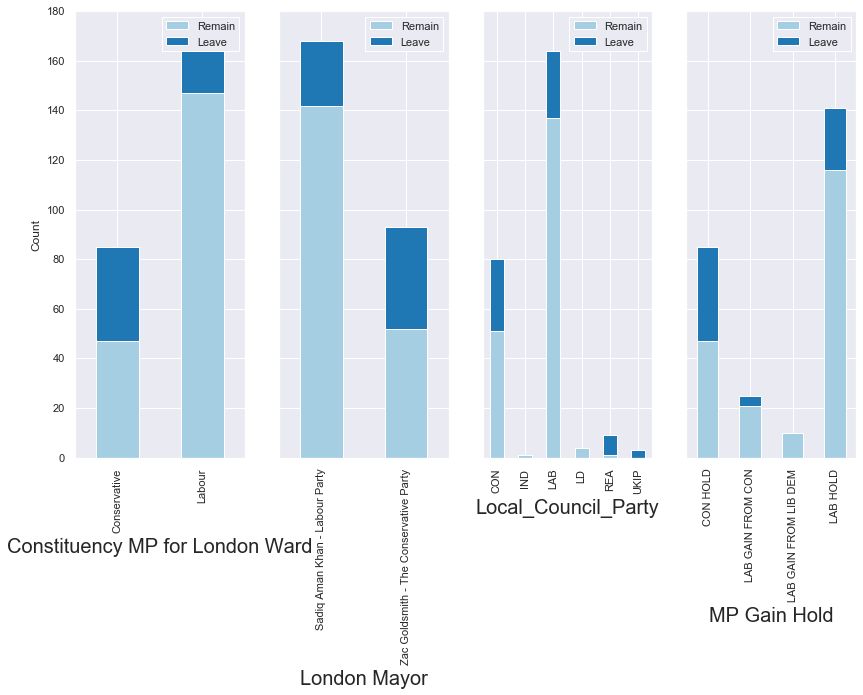

```python
fig, (ax, ax2, ax3, ax4) = plt.subplots(ncols=4, sharey=True)

# London MP
plot_data = final_data.iloc[:,[1,4,5,6,38]]
plot_data = pd.crosstab(index=plot_data["ConstituencyParty"], columns=plot_data["Leave"])
plot_data = plot_data.plot(kind="bar",
                  figsize=(18,18),
                  stacked=True, ax=ax)
plot_data.legend(["Remain", "Leave"])
plot_data.set_ylabel("Count")
plot_data.set_xlabel("Constituency MP for London Ward", fontsize=20)


# London Mayor
plot_data = final_data.iloc[:,[1,4,5,6,38]]
plot_data = pd.crosstab(index=plot_data["London Mayor"], columns=plot_data["Leave"])
plot_data = plot_data.plot(kind="bar",
                  figsize=(18,18),
                  stacked=True, ax=ax2)
plot_data.legend(["Remain", "Leave"])
plot_data.set_ylabel("Ward Count")
plot_data.set_xlabel("London Mayor", fontsize=20)


# London Council Results
plot_data = final_data.iloc[:,[1,4,5,6,38]]
plot_data = pd.crosstab(index=plot_data["Council_Party"], columns=plot_data["Leave"])
plot_data = plot_data.plot(kind="bar",
                  figsize=(4,4),
                  stacked=True, ax=ax3)
plot_data.legend(["Remain", "Leave"])
plot_data.set_ylabel("Ward Count")
plot_data.set_xlabel("Local_Council_Party", fontsize=20)

# London Gain Hold
plot_data = final_data.iloc[:,[1,4,5,6,9,38]]
plot_data = pd.crosstab(index=plot_data["Gain/Hold"], columns=plot_data["Leave"])
plot_data = plot_data.plot(kind="bar",
                  figsize=(14,8),
                  stacked=True, ax=ax4)
plot_data.legend(["Remain", "Leave"])
plot_data.set_ylabel("Ward Count")
plot_data.set_xlabel("MP Gain Hold", fontsize=20)
```

**Note:** Data Model Limitations and Why Ward Level Matters?

- Not all boroughs were able to provide ward based data due to differing vote counting procedures.
- What is the influence of the Postal Vote on our analysis?
- Is keeping % only Values the best approach?
- Ward vs Borough - Should we get missing data from borough dataset or will this skew our analysis?

## Data Inspection and Candidate Feature Selection

**Questions**:

- What Features do we have?
- What might be interesting to look at?
- What Problems might they pose for our analysis?
- What does the data look like?
- What problems might data format or the state it is in present us with?
- Are Age, Education and Diversity Profiles alligned to EU Vote preference?

```python
len(final_data)
final_data.WardCode.value_counts()
final_data.describe()
```

|  | Remain% | Leave% | % Turnout | % Majority | % All Children aged 0-15 - 2015 | % All Working-age (16-64) - 2015 | % All Older people aged 65+ - 2015 | % BAME - 2011 | % Not Born in UK - 2011 | % English is First Language of no one in household - 2011 | % children in reception year who are obese - 2011/12 to 2013/14 | % children in year 6 who are obese- 2011/12 to 2013/14 | % detached houses - 2011 | % semi-detached houses - 2011 | % terraced houses - 2011 | % Flat, maisonette or apartment - 2011 | % Households Owned - 2011 | % Households Social Rented - 2011 | % Households Private Rented - 2011 | % dwellings in council tax bands A or B - 2015 | % dwellings in council tax bands C, D or E - 2015 | % dwellings in council tax bands F, G or H - 2015 | % dependent children (0-18) in out-of-work households - 2014 | % of households with no adults in employment with dependent children - 2011 | % of lone parents not in employment - 2011 | (ID2010) % of LSOAs in worst 50% nationally - 2010 | Unauthorised Absence in All Schools (%) - 2013 | % with no qualifications - 2011 | % with Level 4 qualifications and above - 2011 | … |
| --- | --- | --- | --- | --- | --- | --- | --- | --- | --- | --- | --- | --- | --- | --- | --- | --- | --- | --- | --- | --- | --- | --- | --- | --- | --- | --- | --- | --- | --- | --- |
| count | 261.0000 | 261.0000 | 261.0000 | 261.0000 | 261.0000 | 261.0000 | 261.0000 | 261.0000 | 261.0000 | 261.0000 | 257.0000 | 257.0000 | 261.0000 | 261.0000 | 261.0000 | 261.0000 | 261.0000 | 261.0000 | 261.0000 | 261.0000 | 261.0000 | 261.0000 | 261.0000 | 261.0000 | 261.0000 | 261.0000 | 261.0000 | 261.0000 | 261.0000 | … |
| mean | 58.2628 | 41.7373 | 66.7100 | 24.7418 | 20.0398 | 67.3648 | 12.5939 | 38.0625 | 34.5172 | 12.3310 | 10.3591 | 21.4549 | 7.7720 | 22.9046 | 25.8437 | 43.3958 | 53.8184 | 21.2038 | 22.5839 | 15.6586 | 71.2115 | 13.1333 | 15.6379 | 5.6621 | 45.2709 | 64.7261 | 1.1011 | 18.4257 | 35.6008 | … |
| std | 14.2202 | 14.2203 | 3.9088 | 15.6601 | 3.2983 | 4.6581 | 4.4459 | 19.0202 | 14.1963 | 7.5923 | 3.0659 | 4.8070 | 8.7641 | 15.3539 | 12.7033 | 21.7183 | 17.7229 | 13.2647 | 9.3835 | 12.5488 | 13.4960 | 15.0914 | 7.0979 | 2.9629 | 8.0284 | 36.6520 | 0.3836 | 5.9727 | 12.5380 | … |
| min | 21.0300 | 15.0300 | 58.7000 | 0.3000 | 10.9000 | 57.4000 | 5.1000 | 4.1000 | 5.1000 | 0.4000 | 2.0000 | 9.2000 | 0.3000 | 0.6000 | 1.5000 | 6.3000 | 16.1000 | 1.9000 | 4.8000 | 0.5000 | 24.7000 | 0.0000 | 0.8000 | 1.3000 | 20.8000 | 0.0000 | 0.3000 | 6.1000 | 12.5000 | … |
| 25% | 49.8100 | 29.8000 | 63.7000 | 10.4000 | 17.8000 | 64.4000 | 9.2000 | 22.3000 | 23.8000 | 6.4000 | 8.6000 | 18.1000 | 3.1000 | 11.2000 | 15.8000 | 26.4000 | 41.2000 | 10.0000 | 15.0000 | 5.5000 | 61.9000 | 1.0000 | 10.0000 | 3.4000 | 41.0000 | 33.3000 | 0.8000 | 15.0000 | 26.3000 | … |
| 50% | 57.5900 | 42.4100 | 67.3000 | 26.1000 | 19.8000 | 66.6000 | 11.6000 | 35.7000 | 35.7000 | 11.7000 | 10.7000 | 22.3000 | 4.8000 | 20.2000 | 23.5000 | 39.6000 | 53.1000 | 18.9000 | 23.6000 | 12.3000 | 72.3000 | 6.8000 | 15.8000 | 5.3000 | 46.1000 | 75.0000 | 1.1000 | 17.9000 | 33.5000 | … |
| 75% | 70.2000 | 50.1900 | 69.6000 | 37.5000 | 22.3000 | 70.1000 | 15.4000 | 52.5000 | 44.9000 | 17.5000 | 12.4000 | 24.6000 | 7.8000 | 31.7000 | 35.7000 | 57.2000 | 66.9000 | 30.6000 | 29.3000 | 22.8000 | 82.0000 | 20.3000 | 20.9000 | 7.4000 | 51.3000 | 100.0000 | 1.3000 | 21.9000 | 43.3000 | … |
| max | 84.9700 | 78.9700 | 73.5000 | 55.5000 | 29.6000 | 81.6000 | 24.3000 | 93.7000 | 64.5000 | 36.7000 | 17.6000 | 32.6000 | 55.8000 | 76.2000 | 57.2000 | 97.6000 | 90.8000 | 60.6000 | 45.6000 | 56.0000 | 98.0000 | 74.7000 | 31.9000 | 15.5000 | 62.0000 | 100.0000 | 2.2000 | 35.8000 | 68.3000 | … |

### Look for Correlations and Visually Identify Interesting Features:

final_data.corr()

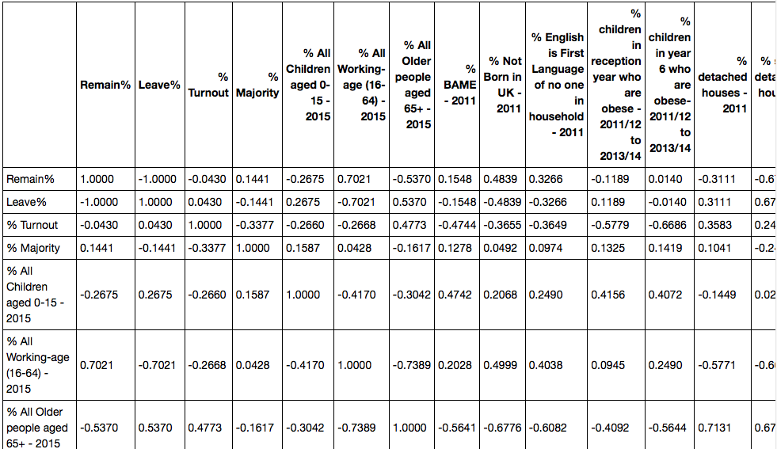

```python
# need code to reduce font size of dataframe ??????
# scatter plots are hard to visually digest with so many features... so looking for alternatives
# scatter_plot = pd.scatter_matrix(scatter_data, alpha=0.2, figsize=(12, 12), diagonal='hist')
# scatter_plot
```

#### Note:

Scatter Plots are very noisy when visualising highly dimensional data. We would still like to visualize the data spread, particularly whether there is any visual grouping of the EU Preference across any given feature.

### Prepare Data for Visual Intro to Data:

- Visually and through use of the Correlation table lets identify notable Features and potential relationships of interest.
- Aggregate Features into groups and look for visual clues related to EU Ref voting preference.

### Create a Categorical Label:

Boolean Label to quickly identify feature patterns or relationships.

```python
# create categorical predictor for hue parameter
# Just Use the % based Features
scatter_data = final_data.filter(regex=('%'))
# scatter_data = final_data
# Create a Categorical Dependent Class
leave_boolean= scatter_data['Leave%'] > scatter_data['Remain%']
scatter_data['Leave'] = leave_boolean.astype('bool')
scatter_data.head(1)
# do we need to format  the % values to less sig digits???
```

|  | Remain% | Leave% | % Turnout | % Majority | % All Children aged 0-15 - 2015 | % All Working-age (16-64) - 2015 | % All Older people aged 65+ - 2015 | % BAME - 2011 | % Not Born in UK - 2011 | % English is First Language of no one in household - 2011 | % children in reception year who are obese - 2011/12 to 2013/14 | % children in year 6 who are obese- 2011/12 to 2013/14 | % detached houses - 2011 | % semi-detached houses - 2011 | % terraced houses - 2011 | % Flat, maisonette or apartment - 2011 | % Households Owned - 2011 | % Households Social Rented - 2011 | % Households Private Rented - 2011 | % dwellings in council tax bands A or B - 2015 | % dwellings in council tax bands C, D or E - 2015 | % dwellings in council tax bands F, G or H - 2015 | % dependent children (0-18) in out-of-work households - 2014 | % of households with no adults in employment with dependent children - 2011 | % of lone parents not in employment - 2011 | (ID2010) % of LSOAs in worst 50% nationally - 2010 | Unauthorised Absence in All Schools (%) - 2013 | % with no qualifications - 2011 | % with Level 4 qualifications and above - 2011 | … |
| --- | --- | --- | --- | --- | --- | --- | --- | --- | --- | --- | --- | --- | --- | --- | --- | --- | --- | --- | --- | --- | --- | --- | --- | --- | --- | --- | --- | --- | --- | --- |
| 0 | 55.7400 | 44.2600 | 67.3000 | 30.8000 | 19.4000 | 60.3000 | 20.4000 | 14.5000 | 15.7000 | 2.7000 | 7.3000 | 12.5000 | 37.0000 | 21.5000 | 17.8000 | 23.7000 | 80.2000 | 7.0000 | 11.4000 | 3.1000 | 49.4000 | 47.5000 | 5.2000 | 2.1000 | 35.6000 | 0.0000 | 0.6000 | 14.5000 | 40.7000 | … |

#### Note:

Lets group the data into categories of feature. We can then run visualations of smaller data sets to more readily aquaint ourselves with the data.

```python
# group by feature type so its easier to visualize in scatter plots
scatter_data_age = scatter_data.iloc[:,[2,3,4,31]]
scatter_data_age.columns = ['Child', 'Working', 'Older', 'Leave']
scatter_data_diversity = scatter_data.iloc[:,[5,6,7,31]]
scatter_data_diversity.columns = ['Bame', 'NotBornUK', 'Not_EL', 'Leave']
scatter_data_education = scatter_data.iloc[:,[25,26,27,31]]
scatter_data_education.columns = ['Unauth', 'NoQ', 'L4Q', 'Leave']

#groups not used
#scatter_data_house = scatter_data.iloc[:,[8,9,10,11,12,13,14,15,16,17,29]]
#scatter_data_house.columns = ['Detach', 'Semi', 'Ter', 'Flat', 'Own', 'SocRent', 'PriRent', 'BandAB', 'BandAC', 'BandFG', 'Leave']
#scatter_data_employment = scatter_data.iloc[:,[18,19,20,29]]
#scatter_data_employment.columns = ['DepChild_OoW', 'NoAdEmp', 'LPNotEmp', 'Leave']
#scatter_data_deprivation  = scatter_data.iloc[:,[21,29]]
#scatter_data_deprivation.columns = ['LSOAW50', 'Leave']
```

```python
#Seaborn Installation temp fix
#import sys
#!conda install --yes --prefix {sys.prefix} seaborn
```

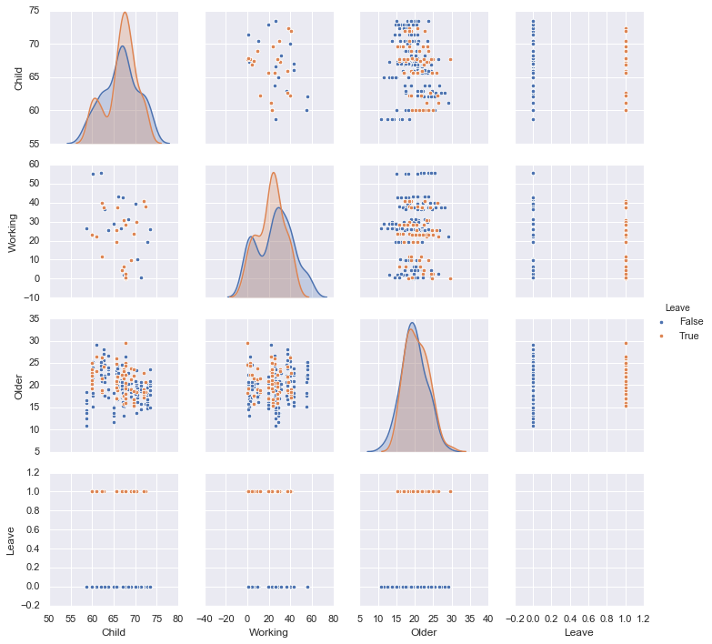

```python
import seaborn as sns
sns.set()
sns.pairplot(scatter_data_age, hue="Leave")
#sns.pairplot(scatter_data_education, hue="Leave")
```

```python
#from pandas.plotting import scatter_matrix
#scatter_plot = scatter_matrix(scatter_data_diversity, alpha=0.9, figsize=(12, 12), diagonal='hist')
#scatter_plot
```

#### Note:

We can see a pattern emerge visually when we use plotting tools recomended for displaying Categorical Values. Here we try a Pairplot, Swarmplot and a scatter plot with two variables.

```python
# Install a conda package in the current Jupyter kernel
#import sys
#!conda install --yes --prefix {sys.prefix} seaborn
```

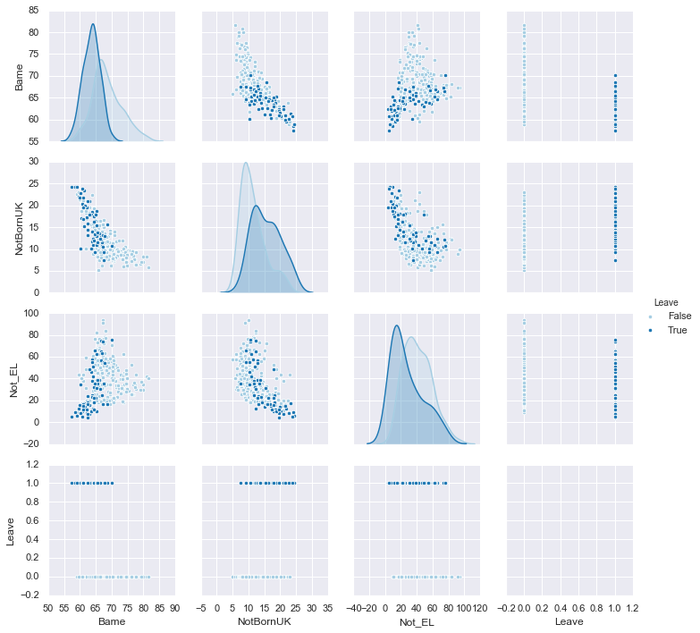

```python
import pandas as pd
import seaborn as sns
sns.set(style="darkgrid", palette="Paired")
sns.pairplot(scatter_data_diversity, hue="Leave")
```

#### Note:

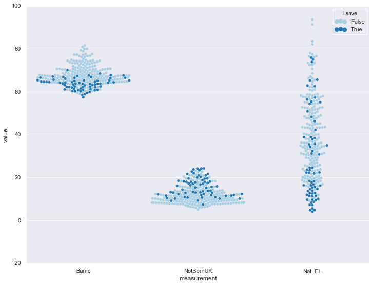

```python
# Get current size
fig_size = plt.rcParams["figure.figsize"]
# Set figure width to 12 and height to 9
fig_size[0] = 12
fig_size[1] = 9
plt.rcParams["figure.figsize"] = fig_size
# "Melt" the dataset to "long-form" or "tidy" representation
scatter_melt = pd.melt(scatter_data_diversity, "Leave", var_name="measurement")
# Draw a categorical scatterplot to show each observation
sns.swarmplot(x="measurement", y="value", hue="Leave", data=scatter_melt)


# Get current size
#fig_size = plt.rcParams["figure.figsize"]
# Set figure width to 12 and height to 9
#fig_size[0] = 12
#fig_size[1] = 9
#plt.rcParams["figure.figsize"] = fig_size

# "Melt" the dataset to "long-form" or "tidy" representation
#scatter_melt = pd.melt(scatter_data_age, "Leave", var_name="measurement")
# Draw a categorical scatterplot to show each observation
#sns.swarmplot(x="measurement", y="value", hue="Leave", data=scatter_melt)
```

#### Note:

```python
#scatter_data.str(['Leave']).apply(lambda x: colors[x])
bool_fix_scatter_data = scatter_data.applymap(lambda x: 1 if x == True else x)
bool_fix_scatter_data = scatter_data.applymap(lambda x: 0 if x == False else x)
bool_fix_scatter_data.head(1)
```

|  | Remain% | Leave% | % Turnout | % Majority | % All Children aged 0-15 - 2015 | % All Working-age (16-64) - 2015 | % All Older people aged 65+ - 2015 | % BAME - 2011 | % Not Born in UK - 2011 | % English is First Language of no one in household - 2011 | % children in reception year who are obese - 2011/12 to 2013/14 | % children in year 6 who are obese- 2011/12 to 2013/14 | % detached houses - 2011 | % semi-detached houses - 2011 | % terraced houses - 2011 | % Flat, maisonette or apartment - 2011 | % Households Owned - 2011 | % Households Social Rented - 2011 | % Households Private Rented - 2011 | % dwellings in council tax bands A or B - 2015 | % dwellings in council tax bands C, D or E - 2015 | % dwellings in council tax bands F, G or H - 2015 | % dependent children (0-18) in out-of-work households - 2014 | % of households with no adults in employment with dependent children - 2011 | % of lone parents not in employment - 2011 | (ID2010) % of LSOAs in worst 50% nationally - 2010 | Unauthorised Absence in All Schools (%) - 2013 | % with no qualifications - 2011 | % with Level 4 qualifications and above - 2011 | … |
| --- | --- | --- | --- | --- | --- | --- | --- | --- | --- | --- | --- | --- | --- | --- | --- | --- | --- | --- | --- | --- | --- | --- | --- | --- | --- | --- | --- | --- | --- | --- |
| 0 | 55.7400 | 44.2600 | 67.3000 | 30.8000 | 19.4000 | 60.3000 | 20.4000 | 14.5000 | 15.7000 | 2.7000 | 7.3000 | 12.5000 | 37.0000 | 21.5000 | 17.8000 | 23.7000 | 80.2000 | 7.0000 | 11.4000 | 3.1000 | 49.4000 | 47.5000 | 5.2000 | 2.1000 | 35.6000 | 0.0000 | 0.6000 | 14.5000 | 40.7000 | … |

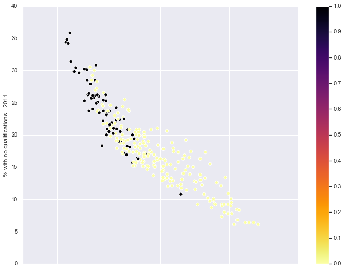

```python
import matplotlib.cm as cm
# Get current size
fig_size = plt.rcParams["figure.figsize"]
# Set figure width to 12 and height to 9
fig_size[0] = 12
fig_size[1] = 9
plt.rcParams["figure.figsize"] = fig_size
#colors = {'True':'red', 'False':'blue'}

#scat = scatter_data.plot.scatter(x='% with Level 4 qualifications and above - 2011', y='% with no qualifications - 2011',
#                        c= scatter_data['Leave'].apply(lambda x: colors[x]), s=50)


#scat = bool_fix_scatter_data.plot.scatter(x='% with Level 4 qualifications and above - 2011', y='% with no qualifications - 2011',
#                        c=bool_fix_scatter_data['Leave'])

scat = bool_fix_scatter_data.plot.scatter(x='% with Level 4 qualifications and above - 2011', y='% with no qualifications - 2011',
                        c=bool_fix_scatter_data['Leave'], cmap=cm.inferno_r, s=40)
```

### Data Prep and Visualisation - Key Findings:

Whilst Education, Age and Diversity combined at this point do not mirror the delineated EU voting camps as strongly as suggested by the BBC article, the visualisation suggests that a relationship might exist, so lets use this as the basis for our Clustering Analysis.

# 2 - Workflow Analysis

## Initial Cluster Analysis

**Goal**: Identify features associated with high leave or high remain vote. We will investigate our chosen features in an Initial Cluster Analysis to identify whther there might be a relationship between EU Voting preference and Census Data that warrants further study.

**Our Chosen Features**:

Age:  
-% All Children aged 0-15 - 2015  
-% All Working-age (16-64) - 2015  
-% All Older people aged 65+ - 2015

Diversity:  
-% BAME - 2011  
-% Not Born in UK - 2011  
-% English is First Language of no one in household - 2011

Education:  
-Unauthorised Absence in All Schools (%) - 2013  
-% with no qualifications - 2011 -% with Level 4 qualifications and above - 2011

## Cluster Method Comparison:

Let's compare a few Clustering Methods to obtain the best Clustering outcome, represented in a Silhouette Score that is closer to 1.

### DBScan Cluster

```python
# pre process
from sklearn.cluster import DBSCAN
quikcluster_data=final_data[['% All Older people aged 65+ - 2015','Leave%']]
import sklearn.preprocessing as preprocessing
scaled_data = preprocessing.scale(quikcluster_data) # add selected Feature
# scaled_data
```

```python
dbscan = DBSCAN(eps=0.5, min_samples=10) # create DBSCAN cluster object
dbscan.fit(scaled_data) # run the .fit() function on the scaled dataset
dbscan_labels = dbscan.labels_
```

```python
from sklearn import metrics
metrics.silhouette_score(scaled_data, dbscan_labels)
```

```
0.3999276775756844
```

### AffinityPropagation Cluster

```python
from sklearn.cluster import AffinityPropagation
af = AffinityPropagation(preference=-50).fit(scaled_data)
af_labels = af.labels_
metrics.silhouette_score(scaled_data, af_labels)
# cluster_centers_indices = af.cluster_centers_indices_
# n_clusters_ = len(cluster_centers_indices)
```

```
0.40613178234567854
```

### KMeans Cluster

```python
from sklearn.cluster import KMeans
kmeans = KMeans(n_clusters=2, random_state=0).fit(scaled_data)
kmeans_labels = kmeans.labels_
metrics.silhouette_score(scaled_data, kmeans_labels)
```

```
0.4533848853412282
```

## Visualize the Cluster Results

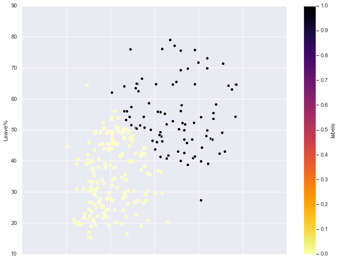

```python
pd.options.mode.chained_assignment = None  # default='warn'
quikcluster_data['labels']=kmeans_labels
quikcluster_data.plot.scatter(x='% All Older people aged 65+ - 2015', y='Leave%', c='labels', cmap=cm.inferno_r, s=40)
```

### Clustering Exploration Analysis:

K Means provides best silhouette score and the Visualisation underlines this: there appears to be a high % of Leavers who are either in the Older Age Grouping, from a Less Diverse area or belong to group who have less qualifications. So let's build on this:

### Step Through All Features Cluster

Having identified K Means as producing the most satisfactory Clustering Result, we will apply the process to the whole set of ring fenced features.

```python
final_data.head(1)
```

|  | WardCode | WardName | Remain% | Leave% | Council_Party | London Mayor | ConstituencyParty | % Turnout | % Majority | Gain/Hold | Ward name | % All Children aged 0-15 - 2015 | % All Working-age (16-64) - 2015 | % All Older people aged 65+ - 2015 | % BAME - 2011 | % Not Born in UK - 2011 | % English is First Language of no one in household - 2011 | % children in reception year who are obese - 2011/12 to 2013/14 | % children in year 6 who are obese- 2011/12 to 2013/14 | % detached houses - 2011 | % semi-detached houses - 2011 | % terraced houses - 2011 | % Flat, maisonette or apartment - 2011 | % Households Owned - 2011 | % Households Social Rented - 2011 | % Households Private Rented - 2011 | % dwellings in council tax bands A or B - 2015 | % dwellings in council tax bands C, D or E - 2015 | % dwellings in council tax bands F, G or H - 2015 | … |
| --- | --- | --- | --- | --- | --- | --- | --- | --- | --- | --- | --- | --- | --- | --- | --- | --- | --- | --- | --- | --- | --- | --- | --- | --- | --- | --- | --- | --- | --- | --- |
| 0 | E05000106 | Bickley | 55.7400 | 44.2600 | CON | Zac Goldsmith - The Conservative Party | Conservative | 67.3000 | 30.8000 | CON HOLD | Bromley - Bickley | 19.4000 | 60.3000 | 20.4000 | 14.5000 | 15.7000 | 2.7000 | 7.3000 | 12.5000 | 37.0000 | 21.5000 | 17.8000 | 23.7000 | 80.2000 | 7.0000 | 11.4000 | 3.1000 | 49.4000 | 47.5000 | … |

```python
cluster_data = final_data.iloc[:,[11,12,13,14,15,16,31,32,33, 3]]
cluster_data
#rename col headers to be more manageable
cluster_data.columns = ['Age_Child', 'Age_Work', 'Age_Older', 'Div_Bame', 'Div_NotBorn', 'Div_EngNot',
                        'Ed_Abs', 'Ed_NoQ', 'Ed_4Q', 'Leave%']


import sklearn.preprocessing as preprocessing
from sklearn.cluster import KMeans

for column in cluster_data:
    print(column)
    step_cluster_data=cluster_data[[column, 'Leave%']]
    #print(step_cluster_data.describe())
    scaled_data_step = preprocessing.scale(step_cluster_data) # add your dataframe name here
    kmeans = KMeans(n_clusters=2, random_state=0).fit(scaled_data_step)
    kmeans_labels = kmeans.labels_
    print(metrics.silhouette_score(scaled_data_step, kmeans_labels))
```

```
Age_Child
0.3851217164948527
Age_Work
0.5055399181014564
Age_Older
0.4533848853412282
Div_Bame
0.40884806649979316
Div_NotBorn
0.49815662789256365
Div_EngNot
0.42091224208441164
Ed_Abs
0.327623732092974
Ed_NoQ
0.4268275724183135
Ed_4Q
0.316033709812216
Leave%
0.5796277664494592
```

### K Means Multi Cluster

```python
multi_cluster_data=final_data[['% All Older people aged 65+ - 2015',
                               '% Not Born in UK - 2011', '% with no qualifications - 2011', 'Leave%']]

import sklearn.preprocessing as preprocessing
scaled_data_multi = preprocessing.scale(multi_cluster_data) # add your dataframe name here
scaled_data_multi
from sklearn.cluster import KMeans
kmeans = KMeans(n_clusters=2, random_state=0).fit(scaled_data_multi)
kmeans_labels = kmeans.labels_
metrics.silhouette_score(scaled_data, kmeans_labels)
```

```
0.4224501623251325
```

**To Do**: Explain variations in Silhouette score? Impact on the decision we make on the Analysis workflow.

### Visualize the Features identified from Clustering Analysis

```python
radviz_data=scatter_data[['% All Older people aged 65+ - 2015',
                               '% Not Born in UK - 2011', '% with no qualifications - 2011',
                                   'Leave']]
```

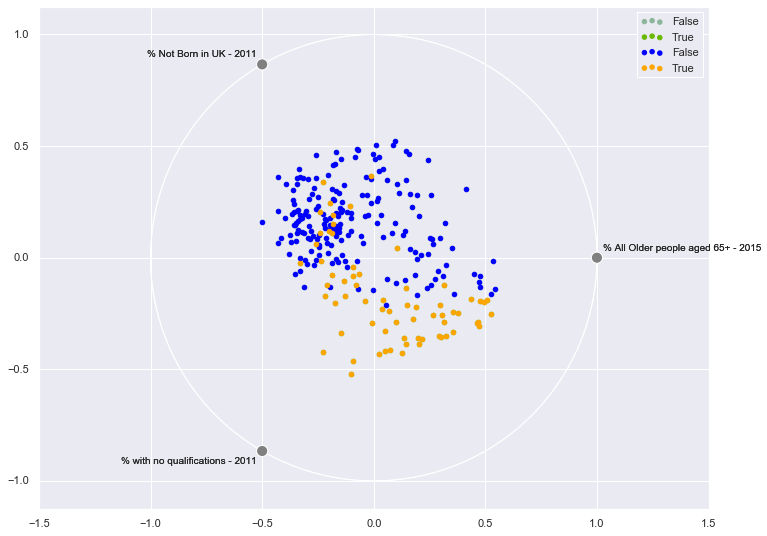

```python
from pandas.plotting import radviz
plt.figure()
radviz(radviz_data, 'Leave')
radviz(radviz_data, 'Leave', color=['blue', 'orange'])
```

### Clustering Analysis Summary:

Our initial Clustering Analysis has further confirmed our visual findings on the possible relationship between EU Voting preference and Age, Education and Diversity Features. We can now proceed to examine the relationship in more depth.

## Building a Classification Model

We will now build a Classification Model following the major steps of a Workflow Analysis: Standardisation, Feature Selection, Hyper Tuning, Model Reorganisation, Cross Validation, Evaluation and Visualisation. We will try a basic SVC Model allowing us the opportunity to try feature selection, hyper parameter tuning methods in order to see if this might improve the model's performance.

```python
# add the categorical dependent class
leave_boolean= final_data['Leave%'] > final_data['Remain%']
final_data['Leave'] = leave_boolean.astype('bool')
#final_data
```

### SVC Classfier

```python
# Split into Labels and Attribute DataFrames

# get col numbers for slice
#len(final_data.columns)

# slice dataset
#attribute_data=final_data.iloc[:,[9,10,11,12,13,14,31,32,33]]
#label_data=final_data.iloc[:,36:]

# re slice dataset
attribute_data=final_data.iloc[:,[11,12,13,14,15,16,33,34,35]]
label_data=final_data.iloc[:,38:]
# inspect data
#attribute_data
#label_data
```

```python
attribute_data.head(1)
label_data.head(1)
```

|  | Leave |
| --- | --- |
| 0 | False |

```python
final_data.head(1)
```

```python
#  insert labels into labelencoder: scikit needs numbers as funny things can happen with text ?????
from sklearn.preprocessing import LabelEncoder
le = LabelEncoder() # creates the LabelEncoder object
labels_fea = le.fit_transform(label_data['Leave']) # runs LabelEncoder on the over50k column
```

```python
# Inspect Data transformation
labels_fea
```

```
array([0, 1, 1, 0, 1, 0, 0, 0, 1, 1, 0, 1, 1, 1, 0, 1, 1, 0, 0, 0, 0, 0,
       0, 0, 0, 0, 0, 0, 0, 0, 0, 0, 0, 1, 0, 0, 0, 1, 1, 0, 1, 0, 0, 0,
       1, 0, 0, 0, 0, 0, 0, 0, 0, 0, 0, 0, 0, 0, 0, 0, 1, 0, 0, 0, 0, 1,
       0, 0, 1, 0, 0, 0, 0, 0, 0, 0, 0, 0, 1, 0, 0, 1, 0, 0, 0, 0, 1, 0,
       0, 0, 0, 0, 0, 0, 1, 0, 0, 1, 0, 0, 1, 1, 1, 1, 0, 0, 0, 0, 0, 1,
       0, 0, 0, 0, 0, 0, 0, 0, 0, 0, 0, 0, 0, 0, 0, 0, 0, 0, 0, 0, 0, 0,
       0, 0, 0, 1, 0, 0, 1, 0, 0, 0, 0, 0, 1, 0, 0, 1, 0, 0, 0, 0, 1, 0,
       1, 1, 1, 1, 1, 1, 1, 1, 1, 1, 1, 1, 1, 1, 1, 1, 1, 1, 1, 0, 0, 0,
       1, 1, 1, 1, 1, 0, 0, 0, 0, 0, 0, 1, 0, 1, 0, 0, 0, 0, 0, 0, 0, 0,
       0, 0, 0, 0, 0, 0, 0, 0, 0, 0, 0, 0, 0, 0, 0, 0, 0, 0, 0, 0, 0, 0,
       0, 0, 0, 0, 0, 0, 0, 0, 0, 0, 0, 1, 0, 0, 1, 0, 1, 0, 0, 0, 0, 0,
       0, 0, 1, 1, 0, 0, 0, 1, 0, 0, 0, 1, 0, 0, 0, 0, 1, 0, 0],
      dtype=int64)
```

```python
# check for null values and blanks in attribute dataset
# check for string objects which will break our z-scores function
attribute_data.count()
attribute_data.dtypes
attribute_data

# we have objects. We could convert these but lets drop these for now
object_columns = attribute_data.select_dtypes(['object']).columns
type(object_columns)
pd.core.index.Index
# drop column by object type.
attribute_data = attribute_data.drop(object_columns, inplace=False, axis=1)

attribute_data.head(1)
```

|  | % All Children aged 0-15 - 2015 | % All Working-age (16-64) - 2015 | % All Older people aged 65+ - 2015 | % BAME - 2011 | % Not Born in UK - 2011 | % English is First Language of no one in household - 2011 | Unauthorised Absence in All Schools (%) - 2013 | % with no qualifications - 2011 | % with Level 4 qualifications and above - 2011 |
| --- | --- | --- | --- | --- | --- | --- | --- | --- | --- |
| 0 | 19.4000 | 60.3000 | 20.4000 | 14.5000 | 15.7000 | 2.7000 | 0.6000 | 14.5000 | 40.7000 |

```python
# Standardardize Data - Numerically Far Apart?

at_scaled=attribute_data
for atr, mean in enumerate(at_scaled.mean()):
    for attri, std in enumerate(at_scaled.std()):
        if atr==attri:
            attribute_data.ix[:,atr]=(at_scaled.ix[:,atr]-mean)/std

#  Can we use Lambda or another scikit tool for doing same conversion ?????

# Inspect Data transformation
at_scaled.head(1)

# Insert Visualisation of transformation or talk about other options ?????
# Identify outliers and smooth out noisy data ????????
```

|  | % All Children aged 0-15 - 2015 | % All Working-age (16-64) - 2015 | % All Older people aged 65+ - 2015 | % BAME - 2011 | % Not Born in UK - 2011 | % English is First Language of no one in household - 2011 | Unauthorised Absence in All Schools (%) - 2013 | % with no qualifications - 2011 | % with Level 4 qualifications and above - 2011 |
| --- | --- | --- | --- | --- | --- | --- | --- | --- | --- |
| 0 | -0.1940 | -1.5167 | 1.7558 | -1.2388 | -1.3255 | -1.2685 | -1.3066 | -0.6573 | 0.4067 |

```python
at_mat = at_scaled.as_matrix()
at_mat
```

```
array([[-0.19399145, -1.51666973,  1.75578665, ..., -1.30659246,
        -0.65727182,  0.40670081],
       [-0.61844938, -1.06583906,  1.57584739, ..., -0.26371591,
        -0.02104091, -1.00500234],
       [ 0.20014806, -1.10877531,  1.0135372 , ..., -0.78515419,
         0.3473033 , -0.58228897],
       ...,
       [ 0.23046648, -0.42179524,  0.27128774, ...,  0.77916064,
         1.28490674, -1.22832261],
       [ 1.07938235,  0.17931233, -0.9882871 , ..., -0.26371591,
         0.33056038, -0.1595756 ],
       [ 1.32192974, -0.22858209, -0.74087061, ..., -0.26371591,
         0.39753206, -0.20742994]])
```

### First Build of Model

```python
# Model Reorganisation / Cross Validation
# Split into Test and Training Dataset

from sklearn.model_selection import train_test_split
train_d, test_d, train_lab, test_lab = train_test_split(at_mat, labels_fea)
len(train_d),len(test_d),len(train_lab),len(test_lab)
```

```
(195, 66, 195, 66)
```

```
              precision    recall  f1-score   support

           0       0.86      0.98      0.91        44
           1       0.94      0.68      0.79        22

    accuracy                           0.88        66
   macro avg       0.90      0.83      0.85        66
weighted avg       0.89      0.88      0.87        66
```

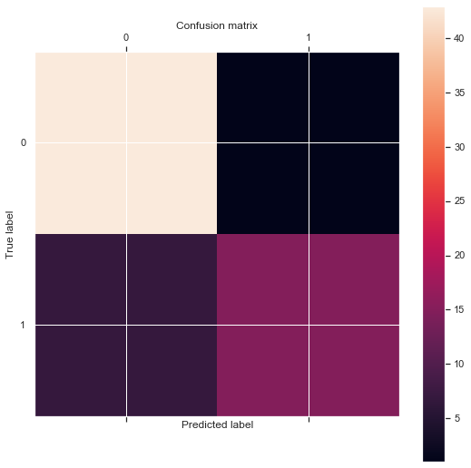

```
SVC(C=100, cache_size=200, class_weight=None, coef0=0.0,
    decision_function_shape='ovr', degree=3, gamma=0.001, kernel='rbf',
    max_iter=-1, probability=False, random_state=None, shrinking=True,
    tol=0.001, verbose=False)
```

```python
# Tune Parameters via GridSearch then re-run Model
from sklearn.model_selection import GridSearchCV
from sklearn.svm import SVC
parameters = {'kernel': ['rbf'], 'gamma': [1e-3, 1e-4, 1e-5],'C': [1, 10, 100, 1000]}
grid_search = GridSearchCV(SVC(), parameters, cv=5, scoring='accuracy')
grid_search.fit(train_d,train_lab)
#grid_search.grid_scores_
grid_search.cv_results_

predictions=grid_search.predict(test_d)

from sklearn import metrics
confusion_matrix = metrics.confusion_matrix(test_lab, predictions)

print (metrics.classification_report(test_lab, predictions))

plt.matshow(confusion_matrix)
plt.title('Confusion matrix')
plt.colorbar()
plt.ylabel('True label')
plt.xlabel('Predicted label')
plt.show()

grid_search.best_estimator_
```

### Key:

#### precision

`Precision is the ability of a classiifer not to label an instance positive that is actually negative. For each class it is defined as as the ratio of true positives to the sum of true and false positives. Said another way, “for all instances classified positive, what percent was correct?”`

#### recall

`Recall is the ability of a classifier to find all positive instances. For each class it is defined as the ratio of true positives to the sum of true positives and false negatives. Said another way, “for all instances that were actually positive, what percent was classified correctly?”`

#### f1 score

`The F1 score is a weighted harmonic mean of precision and recall such that the best score is 1.0 and the worst is 0.0. Generally speaking, F1 scores are lower than accuracy measures as they embed precision and recall into their computation. As a rule of thumb, the weighted average of F1 should be used to compare classifier models, not global accuracy.`

#### support

`Support is the number of actual occurrences of the class in the specified dataset. Imbalanced support in the training data may indicate structural weaknesses in the reported scores of the classifier and could indicate the need for stratified sampling or rebalancing. Support doesn’t change between models but instead diagnoses the evaluation process.`

#### Precision, Recall or f1 Score:

[https://towardsdatascience.com/accuracy-precision-recall-or-f1-331fb37c5cb9`](https://towardsdatascience.com/accuracy-precision-recall-or-f1-331fb37c5cb9%60)

## Analysis:

```python
#Get Numerical Values
print(confusion_matrix)
```

```
[[43  1]
 [ 7 15]]
```

```python
#Array of Test Value Count
unique_elements, counts_elements = np.unique(test_lab, return_counts=True)
print(np.asarray((unique_elements, counts_elements)))
```

```
[[ 0  1]
 [44 22]]
```

### Second Model Build

[output not shown]

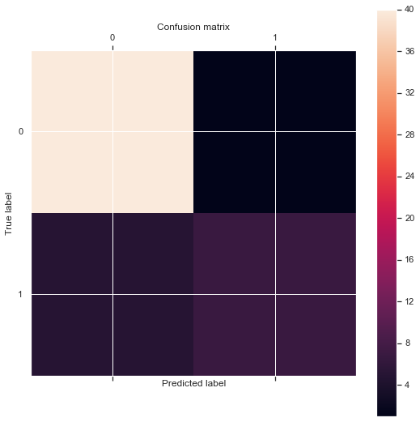

```
SVC(C=1000, cache_size=200, class_weight=None, coef0=0.0,
    decision_function_shape='ovr', degree=3, gamma=0.001, kernel='rbf',
    max_iter=-1, probability=False, random_state=None, shrinking=True,
    tol=0.001, verbose=False)
```

```python
# Feature Selection
# 1st Option is to use PCA
# however we also want to retain meaning in our predictors
from sklearn.decomposition import  PCA
pca = PCA() # create PCA class object
at_decomp = pca.fit_transform(at_mat) # run PCA and write components back to array at_decomp
variance=pca.explained_variance_ratio_
selected={}
for i,value in enumerate(variance):
    if value>=0.1:
        selected[i]=value
selected
selected.keys()
at_decomp_selected=[]
for i in at_decomp:
    at_decomp_selected.append([i[0],i[1],i[2]])
len(at_decomp_selected)

# cross validation for pca treated data
from sklearn.model_selection import train_test_split
train_d, test_d, train_lab, test_lab = train_test_split(at_decomp_selected, labels_fea,test_size=0.20)

# 2nd Option is to use sklearn.feature_selection module
# you can select features based only on their variance (scikit has a function for that).
# While this would not have been necessary with standardised data, see how it can be applied to raw data.

# As an example, suppose that we have a dataset with boolean features,
# and we want to remove all features that are either one or zero (on or off) in more than 80% of the samples.

# Boolean features are Bernoulli random variables, and the variance of such variables is given by
# \mathrm{Var}[X] = p(1 - p)

#so we can select using the threshold .8 * (1 - .8):

#from sklearn.feature_selection import VarianceThreshold
#sel = VarianceThreshold(threshold=(.8 * (1 - .8)))
#sel.fit_transform(attribute_data)

# Feature selection with sparse data ?????
# chi2, mutual_info_regression, mutual_info_classif ?????
# Warning Beware not to use a regression scoring function with a classification problem, ?????
# you will get useless results. ?????
# Tune Parameters via GridSearch then re-run Model

from sklearn.model_selection import GridSearchCV
from sklearn.svm import SVC
parameters = {'kernel': ['rbf'], 'gamma': [1e-3, 1e-4, 1e-5],'C': [1, 10, 100, 1000]}
grid_search = GridSearchCV(SVC(), parameters, cv=5, scoring='accuracy')
grid_search.fit(train_d,train_lab)
grid_search.cv_results_

predictions=grid_search.predict(test_d)

from sklearn import metrics
confusion_matrix = metrics.confusion_matrix(test_lab, predictions)

print (metrics.classification_report(test_lab, predictions))

plt.matshow(confusion_matrix)
plt.title('Confusion matrix')
plt.colorbar()
plt.ylabel('True label')
plt.xlabel('Predicted label')
plt.show()

grid_search.best_estimator_
```

```python
#Get Numerical Values
print(confusion_matrix)
```

[output not shown]

```python
#Array of Test Value Count
unique_elements, counts_elements = np.unique(test_lab, return_counts=True)
print(np.asarray((unique_elements, counts_elements)))
```

```
[[ 0  1]
 [40 13]]
```

## Feature Selection

- For feature selection/dimensionality reduction on sample sets, either to improve estimators’ accuracy scores or to boost their performance on very high-dimensional datasets.

```python
#label_data
```

```python
# re slice dataset
attribute_data=final_data.iloc[:,[11,12,13,14,15,16,33,34,35]]
label_data=final_data.iloc[:,38:]

#  insert labels into labelencoder: scikit needs numeric
from sklearn.preprocessing import LabelEncoder
le = LabelEncoder() # creates the LabelEncoder object
labels_fea = le.fit_transform(label_data['Leave']) # runs LabelEncoder on the over50k column

# retransform the orginal model attribute and labels for feature selection (after having run the model once)
labels_fea.shape
at_mat.shape

attribute_data.as_matrix().shape
label_data.as_matrix().shape
```

```
(261, 1)
```

```python
# trying out feature selection to improve model

from sklearn.feature_selection import SelectKBest
from sklearn.feature_selection import chi2

X, y = attribute_data.as_matrix(), label_data.as_matrix()
X.shape
#SelectKBest removes all but the  highest scoring features
X_new = SelectKBest(chi2, k=2).fit_transform(X, y)
X_new.shape


#X_new
#at_mat
#labels_fea

#from sklearn.feature_selection import VarianceThreshold
#sel = VarianceThreshold(threshold=(.8 * (1 - .8)))
#sel.fit_transform(attribute_data)
```

```
(261, 2)
```

```python
cols
```

[output not shown]

```python
attribute_data.head(1)
```

|  | % All Children aged 0-15 - 2015 | % All Working-age (16-64) - 2015 | % All Older people aged 65+ - 2015 | % BAME - 2011 | % Not Born in UK - 2011 | % English is First Language of no one in household - 2011 | Unauthorised Absence in All Schools (%) - 2013 | % with no qualifications - 2011 | % with Level 4 qualifications and above - 2011 |
| --- | --- | --- | --- | --- | --- | --- | --- | --- | --- |
| 0 | 19.4000 | 60.3000 | 20.4000 | 14.5000 | 15.7000 | 2.7000 | 0.6000 | 14.5000 | 40.7000 |

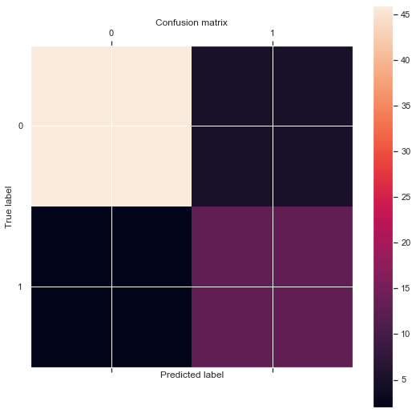

```
              precision    recall  f1-score   support

           0       0.96      0.90      0.93        51
           1       0.72      0.87      0.79        15

    accuracy                           0.89        66
   macro avg       0.84      0.88      0.86        66
weighted avg       0.90      0.89      0.90        66
```

```python
#  2nd Model Build:  run model with feature selected data
from sklearn.model_selection import train_test_split
train_d, test_d, train_lab, test_lab = train_test_split(X_new, labels_fea)
len(train_d),len(test_d),len(train_lab),len(test_lab)
from sklearn.svm import SVC
linear_svc=SVC(kernel='linear')
linear_svc.fit(train_d,train_lab)
linear_svc.score(test_d, test_lab)
predictions = linear_svc.predict(test_d)
from sklearn import metrics
confusion_matrix = metrics.confusion_matrix(test_lab, predictions)

plt.matshow(confusion_matrix)
plt.title('Confusion matrix')
plt.colorbar()
plt.ylabel('True label')
plt.xlabel('Predicted label')
plt.show()
print (metrics.classification_report(test_lab, predictions))
```

```python
#Get Numerical Values
print(confusion_matrix)
```

```
[[46  5]
 [ 2 13]]
```

```python
#Array of Test Value Count
unique_elements, counts_elements = np.unique(test_lab, return_counts=True)
print(np.asarray((unique_elements, counts_elements)))
```

```
[[ 0  1]
 [51 15]]
```

### Recursive Feature Elimination:

Recursively removes features, builds a model using the remaining attributes and calculates model accuracy. RFE is able to work out the combination of attributes that contribute to the prediction on the target variable (or class).

```python
# Recursive Feature Elimination

from sklearn.feature_selection import RFE
from sklearn.svm import SVR
#X, y = make_friedman1(n_samples=50, n_features=10, random_state=0)
X, y = attribute_data.as_matrix(), label_data.as_matrix()
estimator = SVR(kernel="linear")
selector = RFE(estimator, 5, step=1)
selector = selector.fit(X, y)
selector.support_
selector.ranking_
selector

# Recursive Feature Elimination
from sklearn import datasets
from sklearn.feature_selection import RFE
from sklearn.linear_model import LogisticRegression
# load the iris datasets
dataset = datasets.load_iris()
# create a base classifier used to evaluate a subset of attributes
model = LogisticRegression()
# create the RFE model and select 3 attributes
rfe = RFE(model, 3)
#rfe = rfe.fit(dataset.data, dataset.target)
rfe = rfe.fit(attribute_data.as_matrix(), label_data.as_matrix())

# summarize the selection of the attributes
print(rfe.support_)
print(rfe.ranking_)
rfe
```

```python
final_data.iloc[:,[11,12,13,14,15,16,33,34,35]].head(1)
```

### Pipe Lining:

- For linking transformation processes to final estimator
- Benefits include simplify model build stages and neater, modular code
- https://scikit-learn.org/stable/modules/compose.html

```python
# create the pipeline object
#steps = [('scaler', StandardScaler()), ('SVM', SVC())]
#pipeline = Pipeline(steps)

# create the hyperparameter space
#parameters = {'SVM__C':[0.001,0.1,10,100,10e5], 'SVM__gamma':[0.1,0.01]}

#create train and test sets
#X_train, X_test, y_train, y_test = train_test_split(X,Y,test_size=0.2, random_state=30, stratify=Y)

#print X_test.shape

#Grid Search Cross Validation
#grid = GridSearchCV(pipeline, param_grid=parameters, cv=5)
#grid.fit(X_train, y_train)

#print "score = %3.2f" %(grid.score(X_test,y_test))
```

### Basic Optimized Model - Comments:

- We have improved the performance of our Model, however the optimized Models are reflecting some but not all of our variables of interest.
- Will including Election Result as a Percentage provide us with more insight and benefit to the task in hand?

### SVR with % Results

```python
#create our label
leave_boolean= final_data['Leave%'] > final_data['Remain%']
final_data['Leave'] = leave_boolean.astype('bool')
final_data.head(1)
```

```python
# Split into Labels and Attribute DataFrames

# get col numbers for slice
len(final_data.columns)
#final_data.head(1)

# slice dataset
# include mayoral, council, ConstParty, Gain/Hold
attribute_data=final_data.iloc[:,[4,5,6,9,11,12,13,14,15,16,33,34,35]]
label_data=final_data.iloc[:,38:]

# inspect data
attribute_data.head(10)
label_data.head(10)
```

```python
label_data
# check for null values and blanks in attribute dataset
# check for string objects which will break out z-scores function
attribute_data.count()
attribute_data.dtypes
attribute_data

attribute_data = attribute_data.dropna(axis=1, how='all')
attribute_data.fillna(attribute_data.mean())

# we have objects. We could convert these but lets drop these for now
#object_columns = attribute_data.select_dtypes(['object']).columns
#type(object_columns)
#pd.core.index.Index
# drop column by object type.
#attribute_data = attribute_data.drop(object_columns, inplace=False, axis=1)

attribute_data.head(1)
```

```python
label_data.head(1)
```

```python
# deal with categorical data
from sklearn.feature_extraction import DictVectorizer
data_dict = attribute_data.to_dict('records')
data_dict
vec = DictVectorizer()  # create the DictVectorizer object
vec_data = vec.fit_transform(data_dict)  # execute process on the record dictionaries

vec_array = vec_data.toarray()
# vec_array = vec_array[np.logical_not(np.isnan(vec_array))]

#mask = np.all(np.isnan(vec_array) | np.equal(vec_array, 0), axis=1)
#vec_array = vec_array[~mask]
pd.DataFrame(vec_array)

#df.fillna(df.mean())

#import sklearn.preprocessing as preprocessing
#scaled = preprocessing.scale(vec_array)

#from sklearn.preprocessing import LabelEncoder
#le = LabelEncoder() # creates the LabelEncoder object
#labels_fea = le.fit_transform(label_data) # runs LabelEncoder on the over50k column
#labels_fea
```

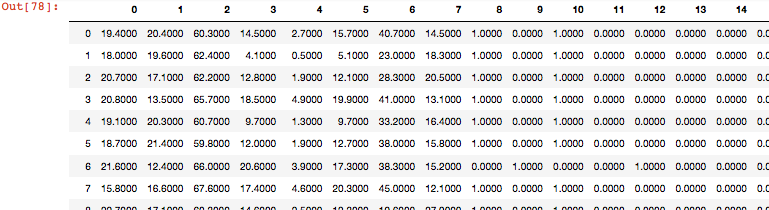

```python
from sklearn.preprocessing import LabelEncoder
le = LabelEncoder() # creates the LabelEncoder object
labels_fea = le.fit_transform(label_data) # runs LabelEncoder on the over50k column
labels_fea
```

```python
#from sklearn.cross_validation import train_test_split
train_d, test_d, train_lab, test_lab = train_test_split(vec_array, labels_fea)
len(train_d),len(test_d),len(train_lab),len(test_lab)

# Tune Parameters via GridSearch then re-run Model
#from sklearn.grid_search import GridSearchCV
from sklearn.svm import SVC
parameters = {'kernel': ['rbf'], 'gamma': [1e-3, 1e-4, 1e-5],'C': [1, 10, 100, 1000]}
grid_search = GridSearchCV(SVC(), parameters, cv=5, scoring='accuracy')
grid_search.fit(train_d,train_lab)
#grid_search.grid_scores_
grid_search.cv_results_

predictions=grid_search.predict(test_d)

from sklearn import metrics
confusion_matrix = metrics.confusion_matrix(test_lab, predictions)

print (metrics.classification_report(test_lab, predictions))

plt.matshow(confusion_matrix)
plt.title('Confusion matrix')
plt.colorbar()
plt.ylabel('True label')
plt.xlabel('Predicted label')
plt.show()

grid_search.best_estimator_
```

```python
#Get Numerical Values
print(confusion_matrix)
```

```python
#Array of Test Value Count
unique_elements, counts_elements = np.unique(test_lab, return_counts=True)
print(np.asarray((unique_elements, counts_elements)))
```

### Logistic Regression

```python
import numpy as np
import pandas as pd
import statsmodels.api as sm
import matplotlib.pyplot as plt

from sklearn.linear_model import LogisticRegression
#from sklearn.cross_validation import train_test_split
from sklearn import metrics
#from sklearn.cross_validation import cross_val_score
from sklearn.model_selection import cross_val_score
```

```python
final_data.groupby('Leave').mean()
```

```python
final_data.head(1)
```

```python
#logistic_data = final_data.iloc[:,[2,3,4,5,6,7,9,10,11,12,13,14,31,32,33]]
#logistic_data

#len(logistic_data.columns)

# Re-slice dataset

attribute_data=final_data.iloc[:,[11,12,13,14,15,16,33,34,35]]
label_data=final_data.iloc[:,[38]]

# inspect data
attribute_data.head(1)
#label_data
```

```python
# check for null values and blanks in attribute dataset
# check for string objects which will break out z-scores function
attribute_data.count()
attribute_data.dtypes
attribute_data

# we have objects. We could convert these but lets drop these for now
object_columns = attribute_data.select_dtypes(['object']).columns
type(object_columns)
pd.core.index.Index
# drop column by object type.
#attribute_data = attribute_data.drop(object_columns, inplace=False, axis=1)

attribute_data.head(1)
#label_data
```

```python
# to do: include other election results(categorical values) in model. Could convert them into Dummy Variables?


#attribute_data=final_data.iloc[:,[2,3,4,5,6,7,9,10,11,12,13,14,31,32,33]]

# deal with categorical data
#from sklearn.feature_extraction import DictVectorizer
#data_dict = attribute_data.to_dict('records')
#data_dict
#vec = DictVectorizer()  # create the DictVectorizer object
#vec_data = vec.fit_transform(data_dict)  # execute process on the record dictionaries
#vec_array = vec_data.toarray()
```

```python
# flatten y into a 1-D array
y = np.ravel(label_data)
X = attribute_data
```

```python
# instantiate a logistic regression model, and fit with X and y
model = LogisticRegression()
model = model.fit(X, y)

# check the accuracy on the training set
model.score(X, y)
```

```python
y.mean()
```

```python
pd.DataFrame(zip(X.columns, np.transpose(model.coef_)))
```

```python
# evaluate the model by splitting into train and test sets
X_train, X_test, y_train, y_test = train_test_split(X, y, test_size=0.3, random_state=0)
model2 = LogisticRegression()
model2.fit(X_train, y_train)
```

```python
# predict class labels for the test set
predicted = model2.predict(X_test)
print(predicted)
```

```python
# generate class probabilities
probs = model2.predict_proba(X_test)
#Get Top 10 Only
print(probs[:10,:2])
```

```python
# generate evaluation metrics
print(metrics.accuracy_score(y_test, predicted))
print(metrics.roc_auc_score(y_test, probs[:, 1]))
```

```python
print(metrics.confusion_matrix(y_test, predicted))
print(metrics.classification_report(y_test, predicted))
```

```python
confusion_matrix = metrics.confusion_matrix(y_test, predicted)
plt.matshow(confusion_matrix)
plt.title('Confusion matrix')
plt.colorbar(cmap=plt.cm.Blues)
plt.ylabel('True label')
plt.xlabel('Predicted label')
plt.imshow(confusion_matrix, interpolation='nearest', cmap=plt.cm.Blues)
plt.show()
```

```python
#Get Numerical Values
print(confusion_matrix)
```

```python
#Array of Test Value Count
unique_elements, counts_elements = np.unique(y_test, return_counts=True)
print(np.asarray((unique_elements, counts_elements)))
```

```python
# evaluate the model using 10-fold cross-validation
scores = cross_val_score(LogisticRegression(), X, y, scoring='accuracy', cv=10)
print(scores)
print(scores.mean())
```

### Note on Visualisation

- What makes a good visualiation? http://matplotlib.org/users/colormaps.html
- Please see Part 2 for additional Spatial Analysis of the Data Model using R Map Tools

## Analysis Workflow - Summary

Age, Diversity and Education categories seem to be associated with dominant voting patterns but definitely not as strongly as suggested in the National Data study. London groups may display more differing and atypical behviours and characteristics from the wider National group of the same class.

The BBC data provided thousands of returned ward result breakdowns. Our final analysis was undertakenon the data frmom under 300 of the over 650+ London Wards.

### Further Study and Improvements

```
- More Analysis breakdown and insight
- More interpretation of our Model build optimisation tweaks and the subsequent gains and losses.
- Code Housekeeping(e.g. repeat Library Declarations, %time helpers etc).
- The Council Control Data Munge may have overlooked split Councils.
- Compare London vs UK in more detail.
- Why Logistic might be more suitable than SVM for this dataset?
- More in depth Time Series Analysis/Voting Pattern Changes over time.
- More Electoral Data: https://www.electoralcommission.org.uk/who-we-are-and-what-we-do/elections-and-referendums/past-elections-and-referendums
- Census 2021 https://www.ons.gov.uk/census/censustransformationprogramme
```

## Conclusion

Given the close call of the EU Referendum result and with June's Snap General Election looming it will be interesting to see whether Voters vote along Party Lines or if there is a move towards a more "Issues Related" focus by the electorate. With most parties all still supporting some form of Brexit, how do the 48% of Remainers feel and how will they vote? As the Campaign trail gathers momentum, what seats and issues will opposition parties focus their attentions on, and how will the Electorate respond to this Summer's call to vote?

The relative success(in terms of prediction accuracy) displayed by this limited model's tentative brush with the ML reservoirs of Python and Scikit, to some extent, hints at how insight on these and related questions can be gained from in depth examination of the Census Data.

Word Count: 1951 Words

### References

**Online**:

Ward Based Study of EU Referendum http://www.bbc.co.uk/news/uk-politics-38762034

Moodle Lecture and Workshop Tutorials for BENVGSA6: Data Science for Spatial Systems(Manley,Grey):  
https://moodle.ucl.ac.uk/course/view.php?id=39453

Logistic Regression Tutorial: http://nbviewer.jupyter.org/gist/justmarkham/6d5c061ca5aee67c4316471f8c2ae976

Areal interpolation and the UK's referendum on EU membership: http://www.tandfonline.com/doi/abs/10.1080/17457289.2017.1287081?journalCode=fbep20

Clustering for Australian Elections:  
http://www.clintonboys.com/aus-election-model-8/

**Technical**:

http://scikit-learn.org/stable/ https://matplotlib.org http://pandas.pydata.org/pandas-docs/version/0.15.2/tutorials.html https://stackoverflow.com/questions/tagged/python

**General Bibliography**

Think Stats: Exploratory Data Analysis in Python http://greenteapress.com/thinkstats2/index.html

Data Science from Scratch: First Principles(Joel Grus)

A Programmers Guide to Data Mining - Ron Zacharski 2012 http://guidetodatamining.com